# (PSL) Random Forest for Regression

```python
import numpy as np
import pandas as pd
import matplotlib.pyplot as plt
import random

from sklearn.ensemble import RandomForestRegressor
from sklearn.model_selection import train_test_split
```

Load the housing dataset.

```python
url = "https://liangfgithub.github.io/Data/HousingData.csv"
Housing = pd.read_csv(url)
Housing.head()
```

|  | Y | chas | lon | lat | crim | zn | indus | nox | rm | age | dis | rad | tax | ptratio | lstat |
| --- | --- | --- | --- | --- | --- | --- | --- | --- | --- | --- | --- | --- | --- | --- | --- |
| 0 | 3.178054 | 0 | -70.955 | 42.2550 | -5.064036 | 1.8 | 0.837248 | -0.619897 | 1.883275 | 3.432567 | 1.408545 | 0.000000 | 5.690359 | 0.454865 | 2.231591 |
| 1 | 3.072693 | 0 | -70.950 | 42.2875 | -3.600502 | 0.0 | 1.955860 | -0.757153 | 1.859574 | 5.529585 | 1.602836 | 0.693147 | 5.488938 | 1.236450 | 3.023243 |
| 2 | 3.546740 | 0 | -70.936 | 42.2830 | -3.601235 | 0.0 | 1.955860 | -0.757153 | 1.971996 | 2.918119 | 1.602836 | 0.693147 | 5.488938 | 1.236450 | 2.007486 |
| 3 | 3.508556 | 0 | -70.928 | 42.2930 | -3.430523 | 0.0 | 0.779325 | -0.780886 | 1.945624 | 1.419592 | 1.802073 | 1.098612 | 5.402677 | 1.772241 | 1.714643 |
| 4 | 3.589059 | 0 | -70.922 | 42.2980 | -2.672924 | 0.0 | 0.779325 | -0.780886 | 1.966693 | 2.162710 | 1.802073 | 1.098612 | 5.402677 | 1.772241 | 2.308679 |

Split the housing data into a training set (70%) and a test set (30%).

```python
random.seed(124)
X = Housing.drop("Y", axis=1)
y = Housing["Y"]

X_train, X_test, y_train, y_test = train_test_split(X, y, test_size=0.3)
```

## Model Fitting

To fit the model, we use the RandomForest function from `sklearn`.

Ref: https://scikit-learn.org/stable/modules/generated/sklearn.ensemble.RandomForestRegressor.html

We aim to predict the variable Y using all other columns in the data matrix as potential predictors. We set the `oob_score` to TRUE (which I’ll explain later), `max_features = 1.0/3`, and specify that the forest should consist of 400 trees.

`max_features`, if float, indicates the fraction of features considered at each split. the number of variables selected for each split. The recommended value for regression-based Random Forest models is 1/3.

```python
rfModel = RandomForestRegressor(n_estimators=400, oob_score=True, max_features = 1.0/3)
rfModel.fit(X_train, y_train);
```

## Making Predictions

```python
yhat = rfModel.predict(X_test)
np.mean((yhat - y_test) ** 2.0)
```

```
0.03189071320016078
```

## Understanding Training Errors

It’s worth discussing the training error. Random Forest provides **two** types of training errors.

The first is obtained by calling the prediction function on the training data, usually resulting in an error rate substantially lower than the test error. This is not surprising, as training errors are generally lower than test errors, especially for complex models.

```python
yhat_train = rfModel.predict(X_train)
np.mean((yhat_train - y_train) ** 2.0)
```

```
0.002657482754564075
```

However, Random Forest also provides a second type of training error—based on so-called out-of-bag samples, if setting `oob_score` to TRUE. This error rate tends to be closer to the test error and serves as a more reliable estimator of the model’s generalization performance.

```python
yhat_train = rfModel.oob_prediction_
np.mean((yhat_train - y_train) ** 2.0)
```

```
0.019421577663267978
```

## Out-of-Bag Samples

What exactly are “Out-of-Bag” samples, and what is the meaning of ‘bag’ in this specific context?

The term “bag” simply refers to a collection or set where the bootstrap samples can be stored. Imagine your original training dataset as being stored in a box. A bootstrap sample is then formed by drawing, with replacement, from this box. These selected samples are placed into a metaphorical “bag.”

In the Random Forest procedure, each tree is built using one such bootstrap sample. Importantly, this bag is unlikely to contain every unique instance from the original training set. The data points not included in a specific bag are termed “Out-of-Bag” (OOB) samples for that tree. These samples serve as test points for evaluating that tree’s performance.

Here’s how it works: Let’s say your Random Forest consists of five trees. Assume that your first training instance, X_1, appears only in the bootstrap samples for the first three trees. When making predictions for X_1, only the last two trees will be used because X_1 is an OOB sample for these trees. Likewise, each data point will have its prediction made from an ensemble of trees for which it is an Out-of-Bag sample.

This prediction methodology makes the OOB error rate akin to a cross-validation error, differing fundamentally from traditional training error.

In R's Random Forest package, you'll find a useful component named 'oob.times'. This feature provides valuable insights by indicating the number of times each training instance was used as an Out-Of-Bag (OOB) sample. This can be helpful for understanding the generalization performance of the model on different subsets of your data.

However, scikit-learn's RandomForest implementation does not directly offer this 'oob.times' feature. While scikit-learn does allow you to calculate OOB error and OOB predictions (by setting `oob_score=True` or using the `oob_prediction_` attribute, respectively) but doesn't provide the specific counts of how many times each training instance was used as an OOB sample.

Since the 'oob.times' information is not readily available in scikit-learn, I recommend **students reviewing the corresponding section in our Rcode page**, which could offer valuable insights.

## Performance Plots

Next, let’s visually examine the performance of our Random Forest model.

The performance plot features the number of trees on the x-axis and their corresponding mean square error (MSE) on the y-axis; each MSE value on the y-axis is calculated based on a forest with the specific number of trees marked on the x-axis. These MSE values are derived from OOB predictions, making them a reliable estimate more akin to cross-validation error than to simple training error.

The plots reveal that the model’s performance improves rapidly with the initial addition of trees but starts to plateau beyond a certain point. This suggests that adding more trees does not lead to overfitting, although one could potentially achieve similar performance with fewer trees, say, just the first 100.

```python
# ref: https://scikit-learn.org/stable/auto_examples/ensemble/plot_ensemble_oob.html
min_estimators = 20
max_estimators = 400

error_rate = []
clf = RandomForestRegressor(oob_score=True)
for i in range(min_estimators, max_estimators + 1):
    clf.set_params(n_estimators=i, warm_start=True)
    clf.fit(X_train, y_train)

    # Record the OOB error for each `n_estimators=i` setting.
    oob_error = np.mean((clf.oob_prediction_ - y_train) ** 2.0)
    error_rate.append((i, oob_error))
```

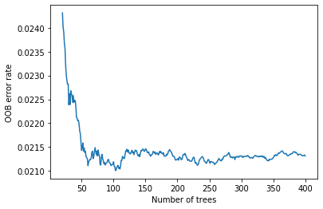

```python
error_rate = np.array([*error_rate])

plt.plot(error_rate[:, 0], error_rate[:, 1])
plt.xlabel("Number of trees")
plt.ylabel("OOB error rate")
```

## Variable Importance

The output `feature_importances_` measures importance based on RSS gain.

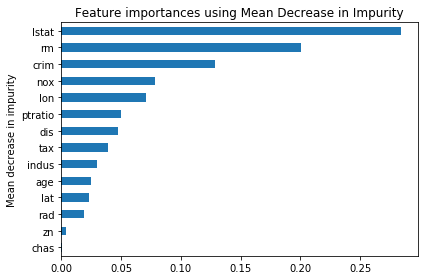

```python
# ref: https://scikit-learn.org/stable/auto_examples/ensemble/plot_forest_importances.html
importances = rfModel.feature_importances_
std = np.std(
    [tree.feature_importances_ for tree in rfModel.estimators_], axis=0)
forest_importances = pd.DataFrame({'Importance': importances}, index=X.columns)
forest_importances = forest_importances.sort_values(by=["Importance"])

fig, ax = plt.subplots()
forest_importances.plot.barh(y="Importance", ax=ax, legend=False)
ax.set_title("Feature importances using Mean Decrease in Impurity")
ax.set_ylabel("Mean decrease in impurity")
fig.tight_layout()
```

For permutation based importance, see sklearn.inspection.permutation_importance